# Climate Change: Analyzing Earth Surface Temperature Data

Team 3: Sonia Clemens, Salim Haruna, Lauren Korlewitz, and Anna Zhu

2021-03-28

# 1. Introduction

### 1.1 Motivation and Research Objectives

Climate change is one of the most widely researched and heavily debated topics of the 21st century, as it not only impacts human systems and the biosphere, but also the hydrosphere, cryosphere, and lithosphere.

In the past decade alone, carbon dioxide concentrations have risen above 400 parts per million (ppm) for the first time in recorded history (Mikhaylov et al., 2020). Rising land temperatures as well as increased frequency of natural disasters (drought, wildfires, flooding, etc,) are reflective of these changes in atmospheric carbon dioxide concentrations. Furthermore, some regions, such as the Arctic, are disproportionately affected by climate change, with mean land surface temperatures warming at twice the global rate in that region (Overland et al., 2017).

### 1.2 Previous Research

While this topic has been extensively researched, many climate change studies are focused on specific climate feedback such as permafrost thaw or Arctic sea ice decline. To add to the already expansive framework of climate change, this project seeks to provide a more broad analysis of temperature change on a global scale over the past two centuries.

# 2. Datasets

### 2.1 Origin

This project will explore regional and global records of temperature using open source earth surface temperature data from Kaggle and the World Bank.

The first dataset from Kaggle contains average surface temperature by country from 1743 to 2013. This dataset consists of more than 544,811 observations and contains four variables: year, average temperature, average temperature uncertainty, and the country in which these temperatures were recorded. Using this dataset, regional and global temperature trends were explored.

The second dataset is sourced from the World Bank and contains data points by country from 1990 to 2013. This dataset consists of 6,336 observations for each of the following categories: CO2 emissions, renewable energy consumption (%), population total, energy use, and forest area. This dataset provides data on the potential predictor variables of surface temperature.

### 2.2 Limitations

The expansive nature of the datasets presented several limitations for analysis. With values ranging from 1743 at the earliest to present times at the latest, the surface temperature dataset specifically needed cleaning and sorting before it could be used for proper exploratory data analysis (EDA) (see “Data Cleaning for Linear Regression”).

First, three new variables were created within the surface temperature data set from Kaggle, including region, century, and decade. Afterwards, the century and decade variables were converted into factor format to allow temperatures to be grouped into certain time periods. The final step in formatting this dataset was to drop missing values. There were many missing values over the long study period that can be traced to a lack of substantial population. For example, many values prior to the 1800s in South America were noticeably void as the region had not yet been colonized.

In the World Bank datasets, there were not as many missing values or formatting issues that needed to be resolved, although the data did require reformatting to be used for this project. The categories of CO2 emissions, renewable energy consumption (%), population total, energy use, and forest area were used as predictor variables in the linear model. To enable EDA using this dataset, the datasets were formatted from wide to long form so that each row would count as a singular observation. Afterwards, data outside of the 1990 to 2013 range was dropped to allow the five variables to be merged together for cleaner processing of the predictor variables in the model. Because some data such as renewable energy use were not measured until the 1990s, this time range was chosen to ensure consistency for the analysis.

# 3. SMART Questions

Based on the research goals and the scope of the datasets, the Specific, Measurable, Achievable, Realistic, and Timely (SMART) questions for the project are as follows:

1. Are surface temperatures changing over time?
2. What factors impact surface temperatures?

For the second SMART question, a linear model was constructed using the following variables: forest area, renewable energy percentage, population totals, energy use, CO2 emissions, and temperatures to predict surface temperatures.

# 4. Exploratory Data Analysis

## 4.1 Import the Data

```r
global_temps <- data.frame(read_csv("Datasets/GlobalTemp.csv"))
global_temps$Region <- countrycode(sourcevar = global_temps[, "Country"],origin = "country.name",destination = "continent")
names(global_temps)[1] <- 'Year'
global_temps$Year <- as.integer(format(global_temps$Year, format="%Y"))
global_temps$Decade <- (global_temps$Year - global_temps$Year %% 10)
global_temps$Century <- (global_temps$Year - global_temps$Year %% 100)
```

## 4.2 Global Temperatures

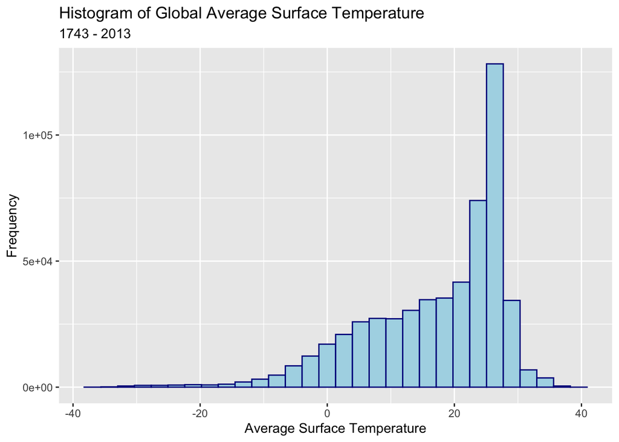

```r
temp_histogram <- ggplot(global_temps, aes(x=AverageTemperature)) +
  geom_histogram(color="dark blue", fill= "lightblue") +
  labs(title ="Histogram of Global Average Surface Temperature", subtitle="1743 - 2013") +
  xlab("Average Surface Temperature") +
  ylab("Frequency")
temp_histogram
```

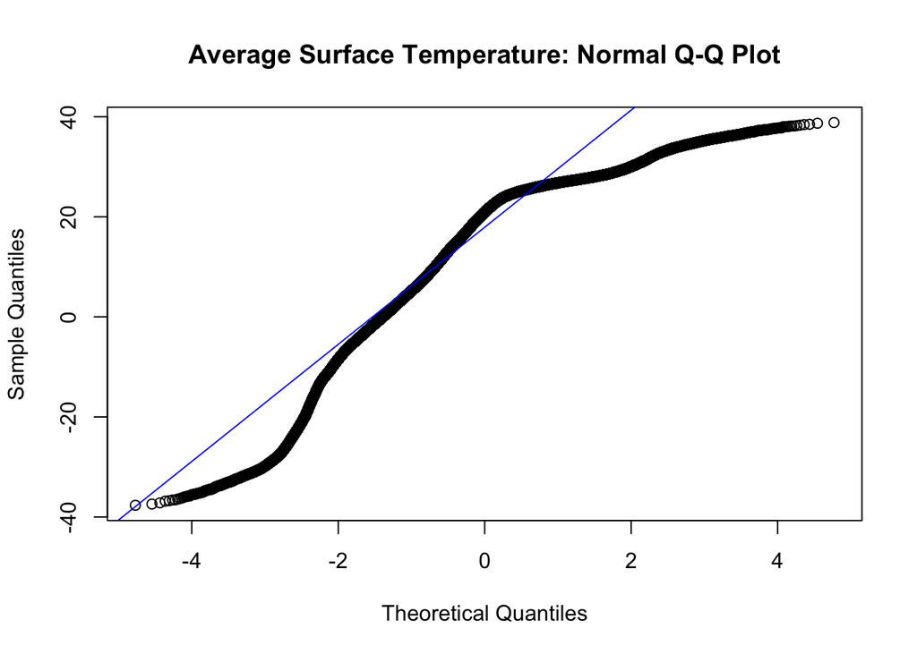

```r
temp_qq <- qqnorm(global_temps$AverageTemperature, main= "Average Surface Temperature: Normal Q-Q Plot"); qqline(global_temps$AverageTemperature, col="blue")
```

```r
temp_qq

summary(global_temps)
sd(global_temps$AverageTemperature)
```

[output not shown]

### 4.2A Histogram

The histogram of global average surface temperature from 1743 to 2013 yielded expected results, with a mean of 17.2 on an overall left skewed distribution. This histogram allowed further analysis since it confirmed that global temperatures fall into an average level of approximately 17 degrees C or 63 degrees F. A value too high or too low would require reassessment of the dataset, since humans require livable temperatures.

### 4.2B Q-Q Plot

The Q-Q plot for average surface temperature supported the conclusions drawn by the histogram, as it also suggested a left skewed distribution, with values peaking towards the middle left of the graph.

## 4.3 Centural Temperatures

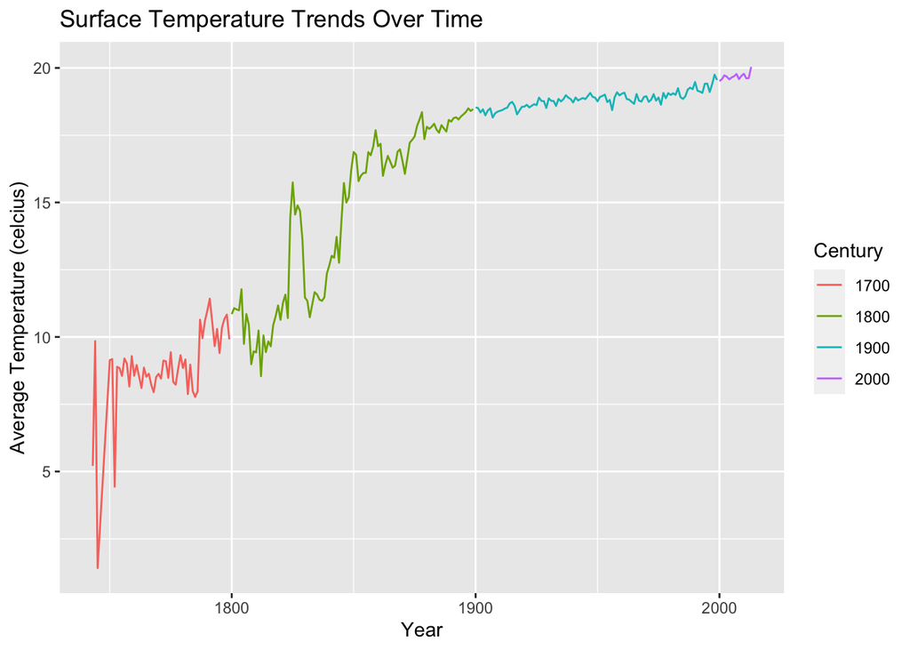

```r
global_temps <-  na.omit(global_temps)
global_temps$Century <- as.factor(global_temps$Century)
global_temps$Decade <- as.factor(global_temps$Decade)

century_temp_data <- global_temps %>% group_by(Century, Year) %>%
  summarize(mean(AverageTemperature))

#line graph of overall trend
century_trends_line_plot <- ggplot() +
  geom_line(data=century_temp_data, aes(x=Year, y=`mean(AverageTemperature)`, color=factor(Century))) +
  xlab("Year") +
  ylab("Average Temperature (celcius)") +
  labs(title="Surface Temperature Trends Over Time", color="Century")
century_trends_line_plot
```

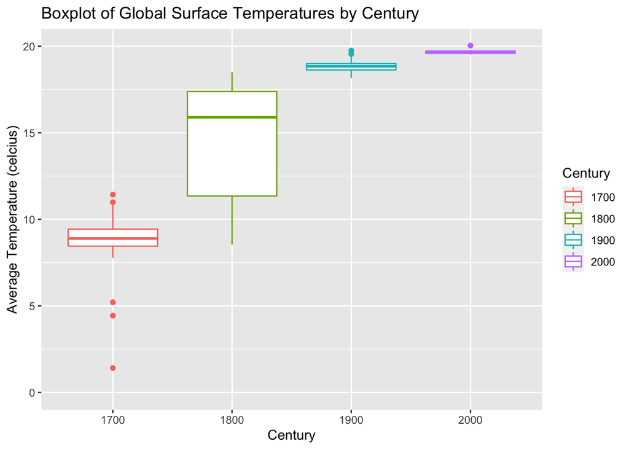

```r
#boxplot by century
century_year_temp_data_boxplot <- ggplot(century_temp_data, aes(x=as.factor(century_temp_data$Century), y=`mean(AverageTemperature)`, color=Century)) +
  geom_boxplot() +
  labs(title="Boxplot of Global Surface Temperatures by Century") +
  xlab("Century") +
  ylab("Average Temperature (celcius)") +
  coord_cartesian(ylim = c(0, 20))
century_year_temp_data_boxplot
```

## 4.4 Regional Temperature

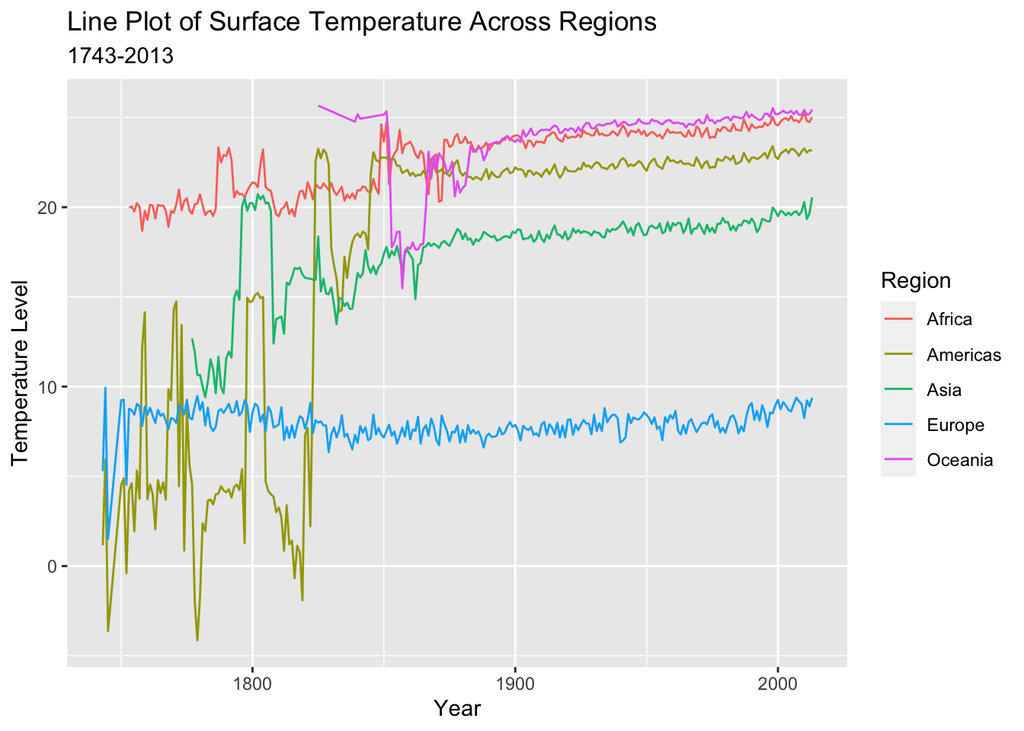

```r
global_temps <-  na.omit(global_temps)
regional_year_temp_data <-  global_temps %>% group_by(Region, Year) %>%
summarize(mean(AverageTemperature))
regional_year_temp_data_line_plot = ggplot() +
  geom_line(data = regional_year_temp_data, aes(x = Year, y = `mean(AverageTemperature)`, group = Region,color=Region)) +
  labs(title="Line Plot of Surface Temperature Across Regions", subtitle="1743-2013") +
  xlab('Year') +
  ylab('Temperature Level') +
  geom_point(size = 4, shape = 21)
regional_year_temp_data_boxplot <- ggplot(regional_year_temp_data, aes(x=as.factor(regional_year_temp_data$Region), y=`mean(AverageTemperature)`, color=Region)) +   labs(title="Boxplot of Surface Temperature Across Regions", subtitle="1743-2013") +
  xlab('Region') +
  ylab('Temperature Level') +
  geom_boxplot()

print(regional_year_temp_data_line_plot)
```

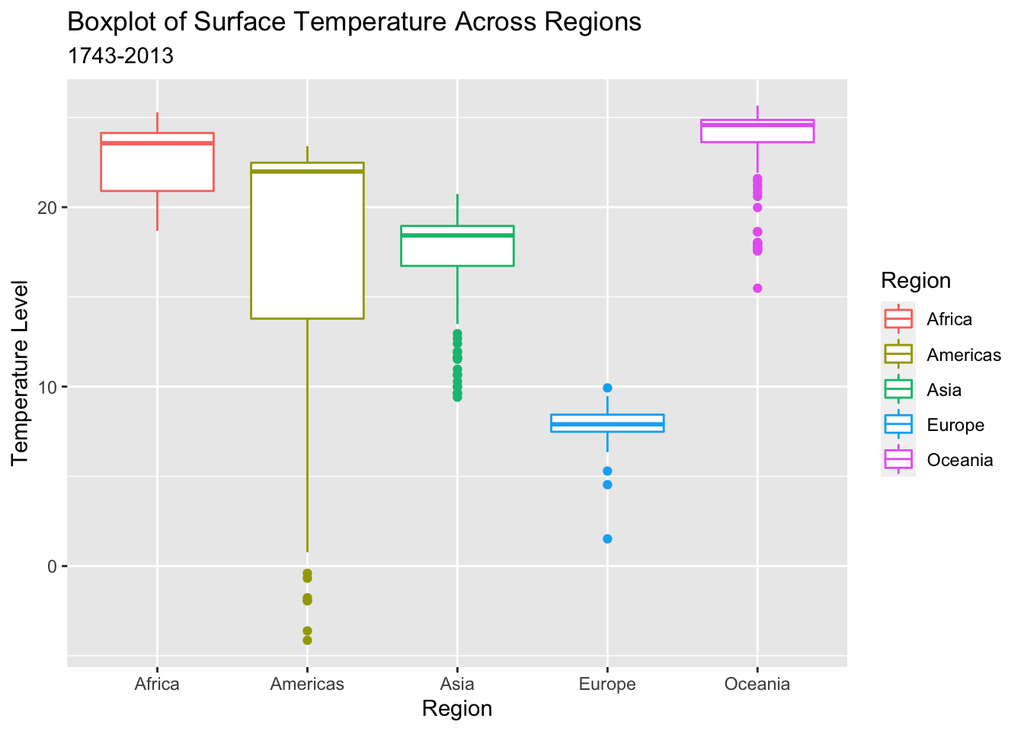

```r
print(regional_year_temp_data_boxplot)
```

# 5. Hypothesis Testing

### 5.1 Anova Test - Do Temperatures Vary by Region?

```r
reginal_aov = aov(`mean(AverageTemperature)` ~ Region, data = regional_year_temp_data)
reginal_aov_summary = summary(reginal_aov)
xkabledply(reginal_aov_summary)
```

[output not shown]

### 5.2 t-test - Are 1900s and 2000s statistically different?

```r
global_temps_1900s <- subset(global_temps, global_temps$Century == "1900")
global_temps_2000s <- subset(global_temps, global_temps$Century == "2000")
century_ttest <- t.test(global_temps_1900s$AverageTemperature, global_temps_2000s$AverageTemperature, alternative = "greater", conf.level = 0.95)
century_ttest
```

[output not shown]

# 6. Model Building

## 6.1 Data Cleaning for Linear Regression

```r
#format dataset to single observation by country per year
summary_temp_data <-  global_temps %>% group_by(Year, Country) %>%
summarize(mean(AverageTemperature))

#reformat World Bank datasets from wide to long (years 1990-2013)
forest_area <- data.frame(read_xls("Datasets/forest_area.xls"))
forest_area <- subset(forest_area, select = -c(2:34))
forest_area <- subset(forest_area, select = -c(26:32))
colnames(forest_area) <- c("Country", "1990", "1991", "1992", "1993", "1994", "1995", "1996", "1997", "1998", "1999",
                           "2000", "2001", "2002", "2003", "2004", "2005", "2006", "2007", "2008", "2009", "2010",
                           "2011", "2012", "2013")
forest_area_long <- gather(forest_area, Year, Forest_Area, 2:25, factor_key = TRUE)

renewable_energy_pct <- data.frame(read_xls("Datasets/renewable_energy.xls"))
renewable_energy_pct <- subset(renewable_energy_pct, select = -c(2:34))
renewable_energy_pct <- subset(renewable_energy_pct, select = -c(26:32))
colnames(renewable_energy_pct) <- c("Country", "1990", "1991", "1992", "1993", "1994", "1995", "1996", "1997", "1998",  "1999","2000", "2001", "2002", "2003", "2004", "2005", "2006", "2007", "2008", "2009", "2010", "2011", "2012", "2013")
renewable_energy_pct_long <- gather(renewable_energy_pct, Year, Renew_Energy_Pct, 2:25, factor_key=TRUE)

population <- data.frame(read_xls("Datasets/population.xls"))
population <- subset(population, select = -c(2:34))
population <- subset(population, select = -c(26:32))
colnames(population) <- c("Country", "1990", "1991", "1992", "1993", "1994", "1995", "1996", "1997", "1998",  "1999","2000", "2001", "2002", "2003", "2004", "2005", "2006", "2007", "2008", "2009", "2010", "2011", "2012", "2013")
population_long <- gather(population, Year, Population_Total, 2:25, factor_key=TRUE)

energy_use <- data.frame(read_xls("Datasets/energy_use.xls"))
energy_use <- subset(energy_use, select = -c(2:34))
energy_use <- subset(energy_use, select = -c(26:32))
colnames(energy_use) <- c("Country", "1990", "1991", "1992", "1993", "1994", "1995", "1996", "1997", "1998",  "1999","2000", "2001", "2002", "2003", "2004", "2005", "2006", "2007", "2008", "2009", "2010", "2011", "2012", "2013")
energy_use_long <- gather(energy_use, Year, Energy_Use, 2:25, factor_key=TRUE)

Co2_emissions <- data.frame(read_xls("Datasets/C02_emissions.xls"))
Co2_emissions <- subset(Co2_emissions, select = -c(2:34))
Co2_emissions <- subset(Co2_emissions, select = -c(26:32))
colnames(Co2_emissions) <- c("Country", "1990", "1991", "1992", "1993", "1994", "1995", "1996", "1997", "1998",  "1999","2000", "2001", "2002", "2003", "2004", "2005", "2006", "2007", "2008", "2009", "2010", "2011", "2012", "2013")
co2_emissions_long <- gather(Co2_emissions, Year, Co2_Emissions, 2:25, factor_key = TRUE)

#merge World Bank Data sets
climate_change1 <- merge(forest_area_long, renewable_energy_pct_long, by=c("Country", "Year"))
climate_change2 <- merge(climate_change1, population_long, by=c("Country", "Year"))
climate_change3 <- merge(climate_change2, energy_use_long, by=c("Country", "Year"))
climate_change <- merge(climate_change3, co2_emissions_long, by=c("Country", "Year"))

#merge with temperature data set
summary_temp_data <- subset(summary_temp_data, summary_temp_data$Year >= 1990)
colnames(summary_temp_data) <- c("Year", "Country", "Temperature")

temp_data <- merge(climate_change, summary_temp_data, by=c("Country", "Year"))
```

## 6.2 Linear Regression

```r
#correlation plot
#remove categorical variables for plot
temp_data_cor <- subset(temp_data, select=-c(1,2))
temp_data_cor[is.na(temp_data_cor)] = 0
tempcor <- cor(temp_data_cor)
corrplot(tempcor, method = "number", type="upper")
```

[output not shown]

```r
#linear model ##Note: Model variables are selected based on variables closer to 1 and -1
model1 <- lm(Temperature ~ Renew_Energy_Pct + Co2_Emissions + Forest_Area  + Population_Total, data=temp_data)
summary(model1)

#rerun without population total
model2 <- lm(Temperature ~ Renew_Energy_Pct + Energy_Use + Co2_Emissions + Forest_Area, data=temp_data)
summary(model2)

faraway::vif(model2)
```

[output not shown]

## 6.3 Model Building and Results

To begin model building, correlation between all numerical variables (forest area, renewable energy percentage, population totals, energy use, CO2 emissions, and temperatures) were examined using a correlation matrix. Based on this plot matrix, all variables could be included in the model. However, it is necessary to consider the correlations between energy usage and CO2 in reality, as environments with higher energy usage tend to have higher CO2 outputs that can cause a rise in temperature as seen in the U.S., China, and India.

The model was revised to include only the statistically significant variables mentioned above, omitting the population total variable. At the 99% confidence level, renewable energy percentage, energy use, CO2 emissions and forest area were found to be statistically significant. A check of the VIF values for the revised model indicated possible multicollinearity as energy use and CO2 emissions returned values over 5. The values, however, were not deemed high enough to remove them from the model.

As such, the equation for our final model read that: Surface temperature (Celsius) = 15.70 + 0.116 * Renew_Energy_Pct - 0.0026 * Energy_Use + 0.9250* CO2_Emissions - 0.0000012* Forest_Area

Where the variable units for renewable energy percent resulted from the percentage of total energy usage and energy use equals kilogram of oil equivalent per capita. CO2 emissions are reported in metric tons per capita and forest area in square kilometers. The R Squared for the revised model is 21.8% .

## 6.4 Regional Linear Regression

### 6.4A Africa

```r
#correlation plot
#remove categorical variables for plot
temp_data$Region <- countrycode(sourcevar = temp_data[, "Country"],origin = "country.name",destination = "continent")
africa_temp_data_cor <- subset(temp_data ,temp_data$Region == 'Africa',select=-c(1,2,9))
africa_temp_data_cor[is.na(africa_temp_data_cor)] = 0
africa_tempcor <- cor(temp_data_cor)
corrplot(africa_tempcor, method = "number", type="upper")
```

[output not shown]

```r
#linear model ##Note: Model variables are selected based on variables closer to 1 and -1
africa_model <- lm(Temperature ~ Energy_Use +Renew_Energy_Pct + Co2_Emissions+ Forest_Area , data=subset(temp_data ,temp_data$Region == 'Africa'))
summary(africa_model)
```

[output not shown]

For the Africa region, the following variables are significant at the 99% confidence level: renewable energy percentage and forest area. The variables found insignificant by the model was energy use and CO2 emissions. The R Squared is 34.5%.

### 6.4B Americas

```r
#correlation plot
#remove categorical variables for plot
temp_data$Region <- countrycode(sourcevar = temp_data[, "Country"],origin = "country.name",destination = "continent")
americas_temp_data_cor <- subset(temp_data ,temp_data$Region == 'Americas',select=-c(1,2,9))
americas_temp_data_cor[is.na(americas_temp_data_cor)] = 0
americas_tempcor <- cor(temp_data_cor)

corrplot(americas_tempcor, method = "number", type="upper")
```

[output not shown]

```r
#linear model ##Note: Model variables are selected based on variables closer to 1 and -1
americas_model <- lm(Temperature ~ Energy_Use + Renew_Energy_Pct + Co2_Emissions + Forest_Area, data=subset(temp_data ,temp_data$Region == 'Americas'))
summary(americas_model)
```

[output not shown]

For the Americas region, all variables are significant at the 99% confidence level. The R Squared is 76.1 % .

### 6.4C Asia

```r
#correlation plot
#remove categorical variables for plot
temp_data$Region <- countrycode(sourcevar = temp_data[, "Country"],origin = "country.name",destination = "continent")
asia_temp_data_cor <- subset(temp_data ,temp_data$Region == 'Asia',select=-c(1,2,9))
asia_temp_data_cor[is.na(asia_temp_data_cor)] = 0
asia_tempcor <- cor(temp_data_cor)
corrplot(asia_tempcor, method = "number", type="upper")
```

[output not shown]

```r
#linear model ##Note: Model variables are selected based on variables closer to 1 and -1
asia_model <- lm(Temperature ~ Energy_Use +Renew_Energy_Pct + Co2_Emissions + Forest_Area, data=subset(temp_data ,temp_data$Region == 'Asia'))
summary(asia_model)
```

[output not shown]

For the Asia region, all variables are significant at the 99% confidence level. The R Squared is 18.2% .

### 6.4D Europe

```r
#correlation plot
#remove categorical variables for plot
temp_data$Region <- countrycode(sourcevar = temp_data[, "Country"],origin = "country.name",destination = "continent")
europe_temp_data_cor <- subset(temp_data ,temp_data$Region == 'Europe',select=-c(1,2,9))
europe_temp_data_cor[is.na(europe_temp_data_cor)] = 0
europe_tempcor <- cor(temp_data_cor)
corrplot(europe_tempcor, method = "number", type="upper")
```

[output not shown]

```r
#linear model ##Note: Model variables are selected based on variables closer to 1 and -1
europe_model <- lm(Temperature ~ Energy_Use +Renew_Energy_Pct + Co2_Emissions + Forest_Area, data=subset(temp_data ,temp_data$Region == 'Europe'))
summary(europe_model)
```

[output not shown]

For the Europe region, the following variables are significant at the 99% confidence level: renewable energy percentage and CO2 emissions. The variables found insignificant by the model was energy use and forest area. The R Squared is 18.8% .

### 6.4E Oceania

```r
#correlation plot
#remove categorical variables for plot
temp_data$Region <- countrycode(sourcevar = temp_data[, "Country"],origin = "country.name",destination = "continent")
oceania_temp_data_cor <- subset(temp_data ,temp_data$Region == 'Oceania',select=-c(1,2,9))
oceania_temp_data_cor[is.na(oceania_temp_data_cor)] = 0
oceania_tempcor <- cor(temp_data_cor)
corrplot(oceania_tempcor, method = "number", type="upper")
```

[output not shown]

```r
#linear model ##Note: Model variables are selected based on variables closer to 1 and -1
oceania_model <- lm(Temperature ~ Energy_Use +Renew_Energy_Pct + Co2_Emissions + Forest_Area, data=subset(temp_data ,temp_data$Region == 'Oceania'))
summary(oceania_model)
```

[output not shown]

For the Oceania region, the following variables are significant at the 99% confidence level: renewable energy percentage, energy use, and CO2 emissions. Forest area is significant at the 95% confidence level. The R Squared is 98.1% .

# 7. Conclusion

## 7.1 Question 1

### 7.1A Are surface temperatures changing over time?

From the boxplot, the Americas region has the highest interquartile range. This makes it the region with the most changed temperature level.

Highest mean surface temperatures were found in Oceania and Africa, followed by the Americas and Asia, with the coldest mean temperatures occurring in Europe

## 7.2 Question 2

### 7.2A What factors impact surface temperatures?

According to the equation, the most influential factor in surface temperature increase is CO2 emissions, which contributes the most to temperature rise. Renewable energy percentage was also found to have a minimal contribution to surface temperature rise, while energy use was found to detract from surface temperature increase. Forested area was also linked to decreases in surface temperature by the revised model and this is consistent with studies that indicate forests to be carbon sinks (Luyssaert et al., 2008).

# 8. Bibliography

Kaggle. (1743–2013). Climate Change: Earth Surface Temperature Data [Dataset]. https://www.kaggle.com/berkeleyearth/climate-change-earth-surface-temperature-data

Luyssaert, S., Schulze, E. D., Börner, A., Knohl, A., Hessenmöller, D., Law, B. E., … & Grace, J. (2008). Old-growth forests as global carbon sinks. Nature, 455(7210), 213-215.

Mikhaylov, A., Moiseev, N., Aleshin, K., & Burkhardt, T. (2020). Global climate change and greenhouse effect. Entrepreneurship and Sustainability Issues, 7(4), 2897.

Overland, J. E., Hanna, E., Hanssen-Bauer, I., Kim, S. J., Walsh, J. E., Wang, M., Bhatt, U.S., & Thoman, R. L. (2017). Surface air temperature. Arctic report card.

World Bank. (1990–2013). CO2 emissions (metric tons per capita) [Dataset]. https://data.worldbank.org/indicator/EN.ATM.CO2E.PC?view=chart

World Bank. (1990–2013b). Energy use (kg of oil equivalent per capita) [Dataset]. https://data.worldbank.org/indicator/EG.USE.PCAP.KG.OE?view=chart

World Bank. (1990–2013c). Forest area (sq. km) [Dataset]. https://data.worldbank.org/indicator/AG.LND.FRST.K2?view=chart

World Bank. (1990–2013d). Population, total [Dataset]. https://data.worldbank.org/indicator/SP.POP.TOTL?view=chart

World Bank. (1990–2013e). Renewable energy consumption (% of total final energy consumption) [Dataset]. https://data.worldbank.org/indicator/EG.FEC.RNEW.ZS?view=chart